# Biomarkers

### Import data

```r
#Imaging/score data
images <- read_excel("~/Documents/ROCIanalysis/ROCI_101918.xlsx", sheet = "Imaging", range = cell_cols(1:16))
images <- images %>% dplyr::select(Subject_ID, Final_Dx, ICU_admit, Intub_date, admit_cxr, Total) %>% rename(score = Total) %>% mutate(Final_Dx = as.factor(Final_Dx)) %>%
  filter(admit_cxr == 1)

#Biomarker data
biomarker <- read_csv("~/Documents/ROCIanalysis/IL18_mtDNA.csv")
biomarker <- biomarker %>% dplyr::select(SID, Date_bld_draw, IL18D0, nadh_copies, HMITO_38, HMITO_96, bglob, Lactate) %>%
  rename(Subject_ID = SID, blood_date = Date_bld_draw) %>%
  filter(!is.na(blood_date)) %>% mutate(blood_date = as.Date(blood_date, "%m/%d/%Y")) %>%
  left_join(images, by = "Subject_ID") %>% filter(admit_cxr == 1)

#Pull APACHE score in from outcomes data
outcome <- read_excel("~/Documents/ROCIanalysis/ROCI_101918.xlsx", sheet = "Outcomes", range = cell_cols(1:10))
outcome <- outcome %>% dplyr::select(Subject_ID, APACHE)
biomarker <- biomarker %>% left_join(outcome, by = "Subject_ID")
```

Per Circulating mitochondrial DNA in patients in the ICU as a marker of mortality: derivation and validation (PLoS Med 2013):  
mtDNA = human NADH dehydrogenase 1 gene (represented in this data as **nadh_copies**)  
nuclear DNA = human B-globin (represented in this data as **bglob**)  
Innate immune response (represented in this data by **IL18D0**, meaning collected wi 48H admission)

### Summary stats

```r
#subjects with both a scored CXR and a given biomarker
markers <- biomarker %>% dplyr::select(IL18D0, nadh_copies, HMITO_38, HMITO_96, Lactate)

#define functions to accomodate missing data
count_rows <- function(x){
  NROW(na.omit(x))
}
max_val <- function(x){
  max(na.omit(x))
}
min_val <- function(x){
  min(na.omit(x))
}

#Build the summary table
sum_stat <- data.table(IL18D0=double(), nadh_copies=double(), HMITO_38=double(), HMITO_96=double(), Lactate=double())
sum_stat <- rbind(sum_stat, t(apply(markers, 2, count_rows)))
sum_stat <- rbind(sum_stat, t(apply(markers, 2, max_val)))
sum_stat <- rbind(sum_stat, t(apply(markers, 2, min_val)))
sum_stat <- cbind(sum_stat, c("n", "max", "min"))
sum_stat <- sum_stat[,c(6,1,2,3,4,5)]
sum_stat
```

```
##     V2     IL18D0 nadh_copies HMITO_38 HMITO_96 Lactate
## 1:   n  200.00000      186.00   157.00   187.00  104.00
## 2: max 4218.35200    20615.83  1509.42  8395.27   29.00
## 3: min   29.72104       14.86     6.52     2.65    0.08
```

## Scatterplot

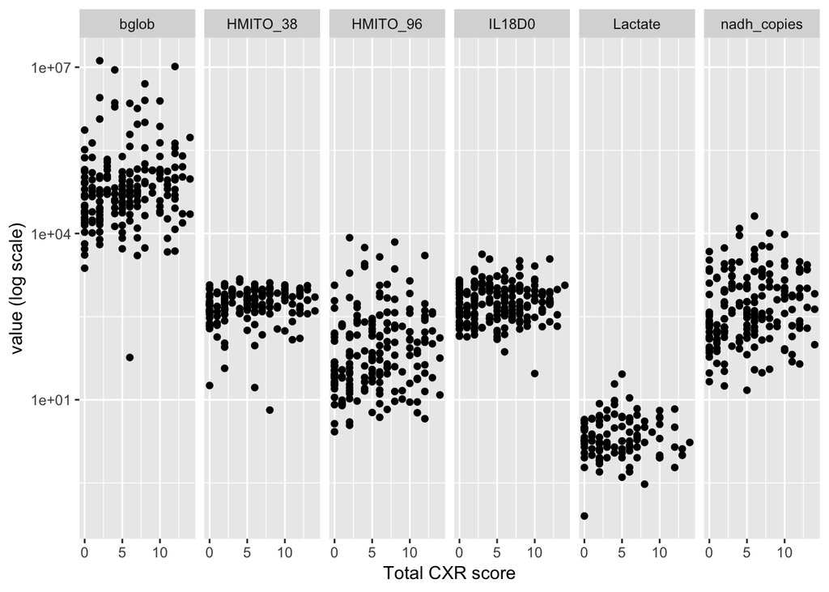

```r
biomarker %>% dplyr::select(IL18D0, nadh_copies, HMITO_38, HMITO_96, bglob, Lactate, score) %>% gather(marker, value, -score, na.rm=T) %>%
  ggplot(aes(score, value)) + geom_point() + scale_y_log10() + facet_grid(.~marker) + ylab("value (log scale)") + xlab("Total CXR score")
```

```r
#To check the integrity of the gather, name the data and check against:
#vert %>% group_by(marker) %>% summarize(count = length(marker)) #check that the gather did not lose any data
```

## Test for normality

```r
shapiro.test(biomarker$IL18D0)
```

```
##
##  Shapiro-Wilk normality test
##
## data:  biomarker$IL18D0
## W = 0.79152, p-value = 1.301e-15
```

```r
shapiro.test(biomarker$nadh_copies)
```

```
##
##  Shapiro-Wilk normality test
##
## data:  biomarker$nadh_copies
## W = 0.49014, p-value < 2.2e-16
```

```r
shapiro.test(biomarker$HMITO_38)
```

```
##
##  Shapiro-Wilk normality test
##
## data:  biomarker$HMITO_38
## W = 0.98623, p-value = 0.1229
```

```r
shapiro.test(biomarker$HMITO_96)
```

```
##
##  Shapiro-Wilk normality test
##
## data:  biomarker$HMITO_96
## W = 0.34251, p-value < 2.2e-16
```

```r
shapiro.test(biomarker$bglob)
```

```
##
##  Shapiro-Wilk normality test
##
## data:  biomarker$bglob
## W = 0.25274, p-value < 2.2e-16
```

```r
shapiro.test(biomarker$Lactate)
```

```
##
##  Shapiro-Wilk normality test
##
## data:  biomarker$Lactate
## W = 0.58481, p-value = 1.09e-15
```

Only HMITO_38 is normally distributed.

### Log transformation

```r
biomarker <- biomarker %>% mutate(logIL18 = log10(IL18D0), logbglob = log10(bglob), lognadh = log10(nadh_copies), logh96 = log10(HMITO_96))

shapiro.test(biomarker$logIL18)
```

```
##
##  Shapiro-Wilk normality test
##
## data:  biomarker$logIL18
## W = 0.99045, p-value = 0.2079
```

```r
shapiro.test(biomarker$lognadh)
```

```
##
##  Shapiro-Wilk normality test
##
## data:  biomarker$lognadh
## W = 0.99287, p-value = 0.5016
```

```r
shapiro.test(biomarker$logh96)
```

```
##
##  Shapiro-Wilk normality test
##
## data:  biomarker$logh96
## W = 0.98027, p-value = 0.009612
```

```r
shapiro.test(biomarker$logbglob)
```

```
##
##  Shapiro-Wilk normality test
##
## data:  biomarker$logbglob
## W = 0.94497, p-value = 1.343e-06
```

Log transforming IL-18 and nadh made those two normally distributed, while HMITO_96 and bglob remain non-normal

## Regressions

```r
biomarker %>% dplyr::select(IL18D0, logIL18, lognadh, HMITO_38, logh96, logbglob, Lactate, score) %>% gather(marker, value, -score, na.rm=T) %>%
  group_by(marker) %>% do(tidy(lm(value~score, data = .))) %>% filter(term != "(Intercept)")
```

```
## # A tibble: 7 x 6
## # Groups:   marker [7]
##   marker   term  estimate std.error statistic p.value
##   <chr>    <chr>    <dbl>     <dbl>     <dbl>   <dbl>
## 1 HMITO_38 score 13.1       6.07        2.15  0.0328
## 2 IL18D0   score 11.6      11.7         0.994 0.321
## 3 Lactate  score  0.0137    0.0969      0.141 0.888
## 4 logbglob score  0.0261    0.0125      2.08  0.0386
## 5 logh96   score  0.0306    0.0126      2.42  0.0164
## 6 logIL18  score  0.00718   0.00625     1.15  0.252
## 7 lognadh  score  0.0291    0.0109      2.66  0.00850
```

The regression demonstrates that CXR score was a significant predictor of HMITO_38, log of nadh, log of HMITO96, log of bglob. It does not appear to be a significant predictor of lactate or IL18 (either untransformed or log transformed).

Since nadh represents mtDNA and bglob represents nucDNA, I can state that CXR severity associates with those.

```r
biomarker %>% dplyr::select(logIL18, lognadh, HMITO_38, logh96, logbglob, Lactate, score, APACHE) %>% gather(marker, value, -score, -APACHE, na.rm=T) %>%
  group_by(marker) %>% do(tidy(lm(value~score+APACHE, data = .))) %>% filter(term != "(Intercept)")
```

```
## # A tibble: 12 x 6
## # Groups:   marker [6]
##    marker   term    estimate std.error statistic      p.value
##    <chr>    <chr>      <dbl>     <dbl>     <dbl>        <dbl>
##  1 HMITO_38 score    5.40      5.89        0.918 0.360
##  2 HMITO_38 APACHE  13.2       2.71        4.86  0.00000284
##  3 Lactate  score   -0.0568    0.102      -0.557 0.579
##  4 Lactate  APACHE   0.0835    0.0426      1.96  0.0528
##  5 logbglob score    0.00826   0.0119      0.694 0.489
##  6 logbglob APACHE   0.0323    0.00550     5.88  0.0000000190
##  7 logh96   score    0.0130    0.0121      1.08  0.283
##  8 logh96   APACHE   0.0319    0.00557     5.74  0.0000000388
##  9 logIL18  score    0.00216   0.00621     0.348 0.728
## 10 logIL18  APACHE   0.0102    0.00276     3.69  0.000289
## 11 lognadh  score    0.0164    0.0106      1.55  0.123
## 12 lognadh  APACHE   0.0246    0.00493     4.99  0.00000140
```

While APACHE is a significant predictor of all the biomarkers (lactate is borderline), with APACHE in the model, the CXR is not significantly predictive of any biomarker.